# Análisis de las condiciones del océano frente a Perú durante el año 1991 y relación de la productividad primaria y la temperatura superficial del mar.

Rolf Rivas

## Introducción

La temperatura y salinidad son las variables más usadas en oceanografía, ya que definen masas de agua y su densidad. Anomalias en la temperatura y salinidad tienen efecto en las comunidades biológicas como el plancton, anchoveta, depredadores superiores entre otros. Durante los años 1991-1992 se registro un Niñoo, el cual fue considerado como moderado (SENAMHI 2014; Tahakashi, 2016). El objetivo de este trabajo es analizar la temperatura, salinidad y fitoplancton del océano frente a Perú para el año **1991**.

## Materiales y métodos

### Materiales

- Para realizar los análisis se usó los datos de temperatura superficial del mar(SST), salinidad (SSS) y fitoplancton (phy) grande y pequeñoo de la liberia netCDF (**Network Common Data Form**). Además se usó el paquete estadistico R y los paquetes de R: markdown, kali, ncdf4 y fields.

### Métodos

- Se realizaron comparaciones entre los promedios totales de las variables y las anomalias.
  - Las anomalias se definieron como: Anomalias=Promedio(todos los años)-Promedio(año 1991)
- Se realizaron gráficos de variación temporal de temperatura superficial del mar, salinidad y fitoplancton durante el año 1991.
- Se realizó una serie de tiempo de temperatura superficial del mar entre los años 1959-2005.

## Resultados y discusión

### Resultado

```r
#llamar paquetes
library(ncdf4)
library(fields)
library(kali)
```

#### **Serie de tiempo del promedio de la temperatura superficial del mar durante los aÃ±os 1959 y 2005.**

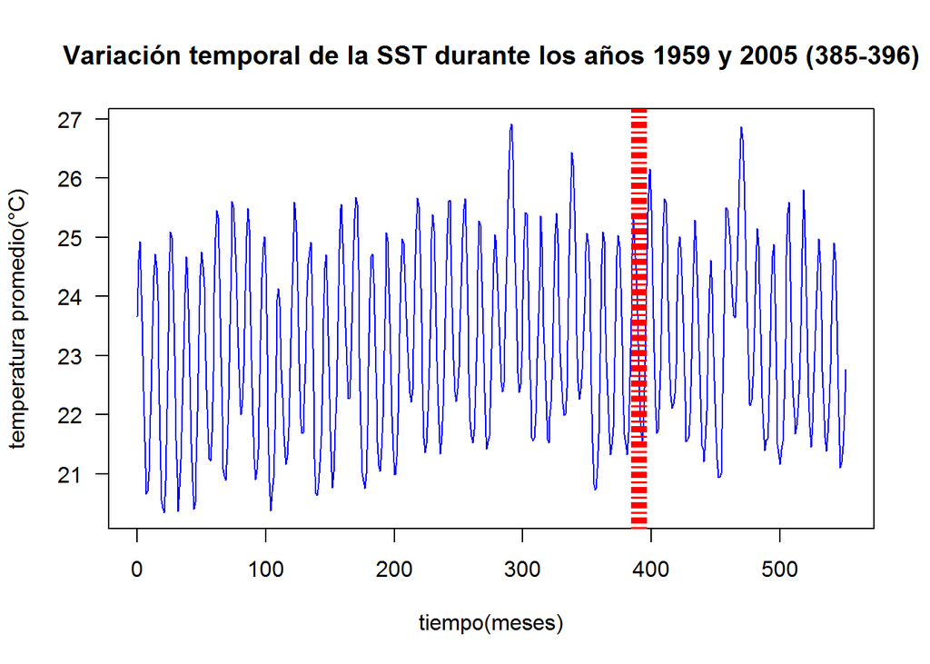

```r
nc_sst=nc_open("datos/sst.nc4")
sst = ncvar_get(nc_sst, "to")
tiempo= ncvar_get(nc_sst, "time")
sst_promedio=apply(sst, MARGIN=3,FUN=mean, na.rm=TRUE)
plot(tiempo, sst_promedio,type="l", col="blue",las=1, xlab="tiempo(meses)",ylab="temperatura promedio(°C)")
title("Variación temporal de la SST durante los años 1959 y 2005 (385-396)")
abline(v=c(385:396),lty=4,col="red")
```

**Figura 1**. Serie de tiempo de la temperatura durante 1959-2005. En rojo el año 1991.

Durante el año 1991 no se distingue ningún pico anormal de temperatura superficial del mar, sin embargo este pico anormal si se puede observar durante finales de 1991 e inicios de 1992 (fig 1).

#### **Análisis de la temperatura superficial del mar, salinidad y fitoplancton durante el año 1991.**

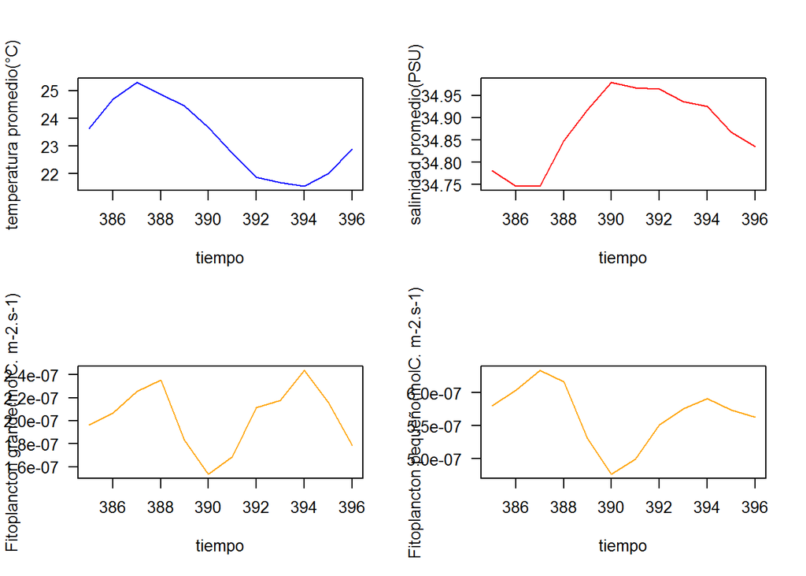

```r
nc_sst=nc_open("datos/sst.nc4")
nc_sss=nc_open("datos/sss.nc4")
nc_lphy=nc_open("datos/lphy.nc4")
nc_sphy=nc_open("datos/sphy.nc4")
sst = ncvar_get(nc_sst, "to")
sss = ncvar_get(nc_sss, "so")
lphy = ncvar_get(nc_lphy, "intpp")
sphy = ncvar_get(nc_sphy, "intpp")
par(mfrow=c(2,2))
tiempo= ncvar_get(nc_sst, "time")
#Grafico promedio de SST
tiempo=c(385:396)
promsst=apply(sst[,,385:396], MARGIN=3,FUN=mean, na.rm=TRUE)
promsss=apply(sss[,,385:396], MARGIN=3,FUN=mean, na.rm=TRUE)
promlphy=apply(lphy[,,385:396], MARGIN=3,FUN=mean, na.rm=TRUE)
promsphy=apply(sphy[,,385:396], MARGIN=3,FUN=mean, na.rm=TRUE)
plot(tiempo,promsst,type="l", col="blue",las=1, xlab="tiempo",ylab="temperatura promedio(°C)")
plot(tiempo,promsss,type="l", col="red",las=1, xlab="tiempo",ylab="salinidad promedio(PSU)")
plot(tiempo,promlphy,type="l", col="orange",las=1, xlab="tiempo",ylab="Fitoplancton grande(molC. m-2.s-1)")
plot(tiempo,promsphy,type="l", col="orange",las=1, xlab="tiempo",ylab="Fitoplancton pequeño(molC. m-2.s-1)")
```

**Figura 2**. Variación temporal mensual de la temperatura superficial del mar, salinidad y productividad primaria durante el año 1991.

#### **Temperatura superficial del mar promedio durante los años 1959-2005 y anomalia para año 1991.**

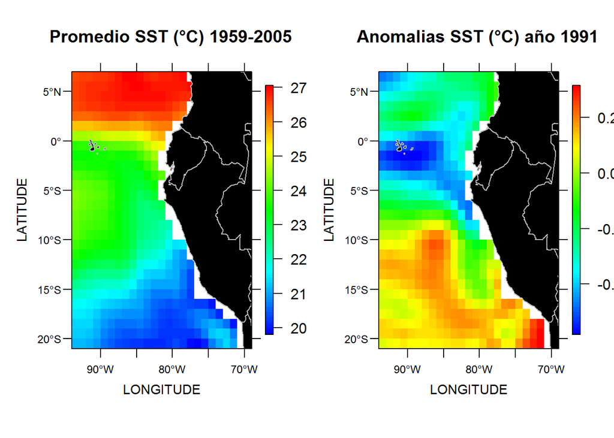

```r
#variable sst
nc_sst=nc_open("datos/sst.nc4")
sst = ncvar_get(nc_sst, "to")
lat = ncvar_get(nc_sst, "latitude")
lon = ncvar_get(nc_sst, "longitude") - 360
tiempo= ncvar_get(nc_sst, "time")
par(mfrow=c(1,2))
#Grafico promedio de SST
sst_promedio=apply(sst[,,1:552], MARGIN = c(1,2), FUN=mean, na.rm = TRUE)
image.map(lon, lat, sst_promedio)
title("Promedio SST (°C) 1959-2005")

#Grafico promedio de año 1991
sst_ano1991=apply(sst[,,385:396], MARGIN = c(1,2), FUN = mean, na.rm = TRUE)
anomalia_sst=sst_promedio-sst_ano1991
image.map(lon, lat, anomalia_sst)
title("Anomalias SST (°C) año 1991")
```

**Figura 3**. Promedio de la temperatura superficial del mar durante los años 1959-2005 y anomalias de la temperatura superficial del mar durante el año 1991.

No hubo anomalía de la temperatura superficial del mar en las zonas central y norte del pacífico frente a Perú, sin embargo se puede observar una pequeña anomalía positiva en la zona sur (fig 3).